# **PROJECT 1 REPORT: Mortality Patterns and Insights for Public Health**

Piyush Patil

Aman Sran

Prasanna Prakash

# **1.1 Data Selection**

The dataset you have contains monthly death counts between the year 2019-2021 in the USA. This dataset appears to be related to public health or mortality statistics. Let's briefly explain the column names that will be part of your project for building linear regression models in R:

# **1.2 Stakeholder**

The Stakeholder for this project is the Federal Department of Public Health of United States of America. The selection of this stakeholder is based on the critical role the department plays in public health surveillance, policy development, and resource allocation, particularly in response to health crises like the COVID-19 pandemic.

The expected impact of the project's results on the Federal Department of Public Health is significant. By analyzing mortality data, including COVID-19-related deaths, the department will gain valuable insights into the factors influencing mortality rates and the specific impact of the pandemic. These insights can inform evidence-based decision-making, resource allocation, and policy development. For example, the department can use the results to assess the effectiveness of public health interventions, allocate resources to vulnerable populations, and tailor future health policies to mitigate the impact of similar health crises.

# **1.3 Objective of the Proposed Research**

Objective of our research is to analyse the patterns in dataset consisting monthly provisional counts of deaths for select causes of death in USA. It is important to understand correlation between causes of death based on diseases.

The stakeholder for this project is the Federal Department of Public Health, USA. The selection of this stakeholder is based on the critical role the department plays in public health surveillance, policy development, and resource allocation, particularly in response to health crises like the COVID-19 pandemic.

The expected impact of the project's results on the Federal Department of Public Health is significant. By analyzing mortality data, including COVID-19-related deaths, the department will gain valuable insights into the factors influencing mortality rates and the specific impact of the pandemic. These insights can inform evidence-based decision-making, resource allocation, and policy development. For example, the department can use the results to assess the effectiveness of public health interventions, allocate resources to vulnerable populations, and tailor future health policies to mitigate the impact of similar health crises.

# **2. Data Exploration**

The Following are the cells exploring the different parts of the data and drawing insights from it For data exploration, we examined column names using the colnames() function, and inspecting the first 10 rows with head(). Further insights were gained using the glimpse() function, revealing that the dataset contains 3,960 rows and 24 columns. This way we had a quick overview of the dataset's structure and content, setting the foundation for subsequent data analysis and modeling in the project.

```r
#loading necessary libraries to enable use of certain functions
library(dplyr)
library(ggplot2)
library(tidyverse)
```

```r
#loading the dataset
data <- read.csv("/AH_Monthly_Provisional_Counts_of_Deaths_for_Select_Causes_of_Death_by_Sex__Age__and_Race_and_Hispanic_Origin.csv")
```

```r
#knowing number of rows & columns of the dataset with function dim()
dim(data)
```

1. 3960

2. 24

```r
#knowing names of the columns of the dataset using function colnames()
colnames(data)
```

1. 'AnalysisDate'

2. 'Date.Of.Death.Year'

3. 'Date.Of.Death.Month'

4. 'Start.Date'

5. 'End.Date'

6. 'Jurisdiction.of.Occurrence'

7. 'Sex'

8. 'Race.Ethnicity'

9. 'AgeGroup'

10. 'AllCause'

11. 'NaturalCause'

12. 'Septicemia..A40.A41.'

13. 'Malignant.neoplasms..C00.C97.'

14. 'Diabetes.mellitus..E10.E14.'

15. 'Alzheimer.disease..G30.'

16. 'Influenza.and.pneumonia..J09.J18.'

17. 'Chronic.lower.respiratory.diseases..J40.J47.'

18. 'Other.diseases.of.respiratory.system..J00.J06.J30.J39.J67.J70.J98.'

19. 'Nephritis..nephrotic.syndrome.and.nephrosis..N00.N07.N17.N19.N25.N27.'

20. 'Symptoms..signs.and.abnormal.clinical.and.laboratory.findings..not.elsewhere.classified..R00.R99.'

21. 'Diseases.of.heart..I00.I09.I11.I13.I20.I51.'

22. 'Cerebrovascular.diseases..I60.I69.'

23. 'COVID.19..U071..Multiple.Cause.of.Death.'

24. 'COVID.19..U071..Underlying.Cause.of.Death.'

```r
#displaying top 10 rows of the dataset using function head()
head(data,10)
```

A data.frame: 10 × 24

|  | AnalysisDate <chr> | Date.Of.Death.Year <int> | Date.Of.Death.Month <int> | Start.Date <chr> | End.Date <chr> | Jurisdiction.of.Occurrence <chr> | Sex <chr> | Race.Ethnicity <chr> | AgeGroup <chr> | AllCause <int> | ⋯ | Alzheimer.disease..G30. <int> | Influenza.and.pneumonia..J09.J18. <int> | Chronic.lower.respiratory.diseases..J40.J47. <int> | Other.diseases.of.respiratory.system..J00.J06.J30.J39.J67.J70.J98. <int> | Nephritis..nephrotic.syndrome.and.nephrosis..N00.N07.N17.N19.N25.N27. <int> | Symptoms..signs.and.abnormal.clinical.and.laboratory.findings..not.elsewhere.classified..R00.R99. <int> | Diseases.of.heart..I00.I09.I11.I13.I20.I51. <int> | Cerebrovascular.diseases..I60.I69. <int> | COVID.19..U071..Multiple.Cause.of.Death. <int> | COVID.19..U071..Underlying.Cause.of.Death. <int> |
| --- | --- | --- | --- | --- | --- | --- | --- | --- | --- | --- | --- | --- | --- | --- | --- | --- | --- | --- | --- | --- | --- |
| 1 | 10/13/2021 | 2019 | 7 | 07/01/2019 | 07/31/2019 | United States | M | Other | 0-4 years | 61 | ⋯ | 0 | 1 | 0 | 1 | 0 | 6 | 0 | 1 | 0 | 0 |
| 2 | 10/13/2021 | 2019 | 9 | 09/01/2019 | 09/30/2019 | United States | F | Other | 25-34 years | 26 | ⋯ | 0 | 0 | 0 | 0 | 0 | 0 | 1 | 1 | 0 | 0 |
| 3 | 10/13/2021 | 2020 | 3 | 03/01/2020 | 03/31/2020 | United States | Female | Other | 0-4 years | 40 | ⋯ | 0 | 1 | 0 | 0 | 0 | 7 | 0 | 0 | 0 | 0 |
| 4 | 10/13/2021 | 2020 | 3 | 03/01/2020 | 03/31/2020 | United States | Female | Other | 5-14 years | 6 | ⋯ | 0 | 1 | 0 | 0 | 0 | 0 | 0 | 0 | 0 | 0 |
| 5 | 10/13/2021 | 2020 | 3 | 03/01/2020 | 03/31/2020 | United States | Female | Other | 15-24 years | 14 | ⋯ | 0 | 0 | 0 | 0 | 0 | 1 | 0 | 0 | 0 | 0 |
| 6 | 10/13/2021 | 2021 | 4 | 04/01/2021 | 04/30/2021 | United States | Male | Other | 0-4 years | 49 | ⋯ | 0 | 0 | 0 | 0 | 0 | 6 | 0 | 0 | 1 | 1 |
| 7 | 10/13/2021 | 2019 | 1 | 01/01/2019 | 01/31/2019 | United States | F | Hispanic | 0-4 years | 182 | ⋯ | 0 | 4 | 0 | 1 | 0 | 22 | 1 | 0 | 0 | 0 |
| 8 | 10/13/2021 | 2019 | 1 | 01/01/2019 | 01/31/2019 | United States | F | Hispanic | 5-14 years | 44 | ⋯ | 0 | 4 | 1 | 0 | 0 | 0 | 0 | 0 | 0 | 0 |
| 9 | 10/13/2021 | 2019 | 1 | 01/01/2019 | 01/31/2019 | United States | F | Hispanic | 15-24 years | 122 | ⋯ | 0 | 0 | 2 | 1 | 2 | 4 | 6 | 1 | 0 | 0 |
| 10 | 10/13/2021 | 2019 | 1 | 01/01/2019 | 01/31/2019 | United States | F | Hispanic | 25-34 years | 198 | ⋯ | 0 | 5 | 2 | 3 | 0 | 2 | 8 | 2 | 0 | 0 |

```r
#displaying more insights about the dataset using function glimpse()
glimpse(data)
```

```
Rows: 3,960
Columns: 24
$ AnalysisDate                                                                                      <chr> …
$ Date.Of.Death.Year                                                                                <int> …
$ Date.Of.Death.Month                                                                               <int> …
$ Start.Date                                                                                        <chr> …
$ End.Date                                                                                          <chr> …
$ Jurisdiction.of.Occurrence                                                                        <chr> …
$ Sex                                                                                               <chr> …
$ Race.Ethnicity                                                                                    <chr> …
$ AgeGroup                                                                                          <chr> …
$ AllCause                                                                                          <int> …
$ NaturalCause                                                                                      <int> …
$ Septicemia..A40.A41.                                                                              <int> …
$ Malignant.neoplasms..C00.C97.                                                                     <int> …
$ Diabetes.mellitus..E10.E14.                                                                       <int> …
$ Alzheimer.disease..G30.                                                                           <int> …
$ Influenza.and.pneumonia..J09.J18.                                                                 <int> …
$ Chronic.lower.respiratory.diseases..J40.J47.                                                      <int> …
$ Other.diseases.of.respiratory.system..J00.J06.J30.J39.J67.J70.J98.                                <int> …
$ Nephritis..nephrotic.syndrome.and.nephrosis..N00.N07.N17.N19.N25.N27.                             <int> …
$ Symptoms..signs.and.abnormal.clinical.and.laboratory.findings..not.elsewhere.classified..R00.R99. <int> …
$ Diseases.of.heart..I00.I09.I11.I13.I20.I51.                                                       <int> …
$ Cerebrovascular.diseases..I60.I69.                                                                <int> …
$ COVID.19..U071..Multiple.Cause.of.Death.                                                          <int> …
$ COVID.19..U071..Underlying.Cause.of.Death.                                                        <int> …
```

# **3.Data Cleaning**

Data cleaning was performed to enhance the dataset's quality and consistency. Two key steps were taken:

Column Removal: Since this data is of USA the columns named 'Jurisdiction.of.Occurrence' was redundant (all values were same). similarly, 'AnalysisDate' column was not adding value to the data. Hence they were subsequently deleted from the dataset. This streamlines the dataset and removes unnecessary information. Gender Standardization: In the 'Sex' column, entries for gender were not uniform, with variations like 'F,' 'Female,' 'Male,' and 'M.' To ensure consistency and uniformity, the mutate function was employed to standardize the gender entries, ensuring that all gender values follow a consistent format.

Deletion of 2 columns :

```r
#since the columns named 'Jurisdiction.of.Occurrence' & 'AnalysisDate' does not add any value to the data, we can delete them
data <- data[, !colnames(data) %in% c("Jurisdiction.of.Occurrence","AnalysisDate")]
head(data)
```

A data.frame: 6 × 22

|  | Date.Of.Death.Year <int> | Date.Of.Death.Month <int> | Start.Date <chr> | End.Date <chr> | Sex <chr> | Race.Ethnicity <chr> | AgeGroup <chr> | AllCause <int> | NaturalCause <int> | Septicemia..A40.A41. <int> | ⋯ | Alzheimer.disease..G30. <int> | Influenza.and.pneumonia..J09.J18. <int> | Chronic.lower.respiratory.diseases..J40.J47. <int> | Other.diseases.of.respiratory.system..J00.J06.J30.J39.J67.J70.J98. <int> | Nephritis..nephrotic.syndrome.and.nephrosis..N00.N07.N17.N19.N25.N27. <int> | Symptoms..signs.and.abnormal.clinical.and.laboratory.findings..not.elsewhere.classified..R00.R99. <int> | Diseases.of.heart..I00.I09.I11.I13.I20.I51. <int> | Cerebrovascular.diseases..I60.I69. <int> | COVID.19..U071..Multiple.Cause.of.Death. <int> | COVID.19..U071..Underlying.Cause.of.Death. <int> |
| --- | --- | --- | --- | --- | --- | --- | --- | --- | --- | --- | --- | --- | --- | --- | --- | --- | --- | --- | --- | --- | --- |
| 1 | 2019 | 7 | 07/01/2019 | 07/31/2019 | M | Other | 0-4 years | 61 | 52 | 0 | ⋯ | 0 | 1 | 0 | 1 | 0 | 6 | 0 | 1 | 0 | 0 |
| 2 | 2019 | 9 | 09/01/2019 | 09/30/2019 | F | Other | 25-34 years | 26 | 8 | 0 | ⋯ | 0 | 0 | 0 | 0 | 0 | 0 | 1 | 1 | 0 | 0 |
| 3 | 2020 | 3 | 03/01/2020 | 03/31/2020 | Female | Other | 0-4 years | 40 | 35 | 0 | ⋯ | 0 | 1 | 0 | 0 | 0 | 7 | 0 | 0 | 0 | 0 |
| 4 | 2020 | 3 | 03/01/2020 | 03/31/2020 | Female | Other | 5-14 years | 6 | 4 | 1 | ⋯ | 0 | 1 | 0 | 0 | 0 | 0 | 0 | 0 | 0 | 0 |
| 5 | 2020 | 3 | 03/01/2020 | 03/31/2020 | Female | Other | 15-24 years | 14 | 2 | 0 | ⋯ | 0 | 0 | 0 | 0 | 0 | 1 | 0 | 0 | 0 | 0 |
| 6 | 2021 | 4 | 04/01/2021 | 04/30/2021 | Male | Other | 0-4 years | 49 | 42 | 0 | ⋯ | 0 | 0 | 0 | 0 | 0 | 6 | 0 | 0 | 1 | 1 |

Since in the column "Sex", the entries of gender are not uniform (F,Female,Male,M). To bring uniformity we use Mutate() function as :

```r
# Replace 'F' with 'Female' and 'M' with 'Male' in the 'sex' column
data <- data %>%
  mutate(Sex = case_when(
    Sex == 'F' ~ 'Female',
    Sex == 'M' ~ 'Male',
    TRUE ~ Sex
  ))

head(data,10)
```

A data.frame: 10 × 22

|  | Date.Of.Death.Year <int> | Date.Of.Death.Month <int> | Start.Date <chr> | End.Date <chr> | Sex <chr> | Race.Ethnicity <chr> | AgeGroup <chr> | AllCause <int> | NaturalCause <int> | Septicemia..A40.A41. <int> | ⋯ | Alzheimer.disease..G30. <int> | Influenza.and.pneumonia..J09.J18. <int> | Chronic.lower.respiratory.diseases..J40.J47. <int> | Other.diseases.of.respiratory.system..J00.J06.J30.J39.J67.J70.J98. <int> | Nephritis..nephrotic.syndrome.and.nephrosis..N00.N07.N17.N19.N25.N27. <int> | Symptoms..signs.and.abnormal.clinical.and.laboratory.findings..not.elsewhere.classified..R00.R99. <int> | Diseases.of.heart..I00.I09.I11.I13.I20.I51. <int> | Cerebrovascular.diseases..I60.I69. <int> | COVID.19..U071..Multiple.Cause.of.Death. <int> | COVID.19..U071..Underlying.Cause.of.Death. <int> |
| --- | --- | --- | --- | --- | --- | --- | --- | --- | --- | --- | --- | --- | --- | --- | --- | --- | --- | --- | --- | --- | --- |
| 1 | 2019 | 7 | 07/01/2019 | 07/31/2019 | Male | Other | 0-4 years | 61 | 52 | 0 | ⋯ | 0 | 1 | 0 | 1 | 0 | 6 | 0 | 1 | 0 | 0 |
| 2 | 2019 | 9 | 09/01/2019 | 09/30/2019 | Female | Other | 25-34 years | 26 | 8 | 0 | ⋯ | 0 | 0 | 0 | 0 | 0 | 0 | 1 | 1 | 0 | 0 |
| 3 | 2020 | 3 | 03/01/2020 | 03/31/2020 | Female | Other | 0-4 years | 40 | 35 | 0 | ⋯ | 0 | 1 | 0 | 0 | 0 | 7 | 0 | 0 | 0 | 0 |
| 4 | 2020 | 3 | 03/01/2020 | 03/31/2020 | Female | Other | 5-14 years | 6 | 4 | 1 | ⋯ | 0 | 1 | 0 | 0 | 0 | 0 | 0 | 0 | 0 | 0 |
| 5 | 2020 | 3 | 03/01/2020 | 03/31/2020 | Female | Other | 15-24 years | 14 | 2 | 0 | ⋯ | 0 | 0 | 0 | 0 | 0 | 1 | 0 | 0 | 0 | 0 |
| 6 | 2021 | 4 | 04/01/2021 | 04/30/2021 | Male | Other | 0-4 years | 49 | 42 | 0 | ⋯ | 0 | 0 | 0 | 0 | 0 | 6 | 0 | 0 | 1 | 1 |
| 7 | 2019 | 1 | 01/01/2019 | 01/31/2019 | Female | Hispanic | 0-4 years | 182 | 162 | 4 | ⋯ | 0 | 4 | 0 | 1 | 0 | 22 | 1 | 0 | 0 | 0 |
| 8 | 2019 | 1 | 01/01/2019 | 01/31/2019 | Female | Hispanic | 5-14 years | 44 | 28 | 1 | ⋯ | 0 | 4 | 1 | 0 | 0 | 0 | 0 | 0 | 0 | 0 |
| 9 | 2019 | 1 | 01/01/2019 | 01/31/2019 | Female | Hispanic | 15-24 years | 122 | 45 | 0 | ⋯ | 0 | 0 | 2 | 1 | 2 | 4 | 6 | 1 | 0 | 0 |
| 10 | 2019 | 1 | 01/01/2019 | 01/31/2019 | Female | Hispanic | 25-34 years | 198 | 100 | 1 | ⋯ | 0 | 5 | 2 | 3 | 0 | 2 | 8 | 2 | 0 | 0 |

# **4.Adaptation**

Addition of Columns :

```r
# we have two columns for Date of death as 'Date.Of.Death.Year' & 'Date.Of.Death.Month'. Let's create a new columns which will display the Date of death combining month & year :
data$Date_of_Death_YM <- paste(data$Date.Of.Death.Year, data$Date.Of.Death.Month, sep = "-")
head(data,10)
```

A data.frame: 10 × 23

|  | Date.Of.Death.Year <int> | Date.Of.Death.Month <int> | Start.Date <chr> | End.Date <chr> | Sex <chr> | Race.Ethnicity <chr> | AgeGroup <chr> | AllCause <int> | NaturalCause <int> | Septicemia..A40.A41. <int> | ⋯ | Influenza.and.pneumonia..J09.J18. <int> | Chronic.lower.respiratory.diseases..J40.J47. <int> | Other.diseases.of.respiratory.system..J00.J06.J30.J39.J67.J70.J98. <int> | Nephritis..nephrotic.syndrome.and.nephrosis..N00.N07.N17.N19.N25.N27. <int> | Symptoms..signs.and.abnormal.clinical.and.laboratory.findings..not.elsewhere.classified..R00.R99. <int> | Diseases.of.heart..I00.I09.I11.I13.I20.I51. <int> | Cerebrovascular.diseases..I60.I69. <int> | COVID.19..U071..Multiple.Cause.of.Death. <int> | COVID.19..U071..Underlying.Cause.of.Death. <int> | Date_of_Death_YM <chr> |
| --- | --- | --- | --- | --- | --- | --- | --- | --- | --- | --- | --- | --- | --- | --- | --- | --- | --- | --- | --- | --- | --- |
| 1 | 2019 | 7 | 07/01/2019 | 07/31/2019 | Male | Other | 0-4 years | 61 | 52 | 0 | ⋯ | 1 | 0 | 1 | 0 | 6 | 0 | 1 | 0 | 0 | 2019-7 |
| 2 | 2019 | 9 | 09/01/2019 | 09/30/2019 | Female | Other | 25-34 years | 26 | 8 | 0 | ⋯ | 0 | 0 | 0 | 0 | 0 | 1 | 1 | 0 | 0 | 2019-9 |
| 3 | 2020 | 3 | 03/01/2020 | 03/31/2020 | Female | Other | 0-4 years | 40 | 35 | 0 | ⋯ | 1 | 0 | 0 | 0 | 7 | 0 | 0 | 0 | 0 | 2020-3 |
| 4 | 2020 | 3 | 03/01/2020 | 03/31/2020 | Female | Other | 5-14 years | 6 | 4 | 1 | ⋯ | 1 | 0 | 0 | 0 | 0 | 0 | 0 | 0 | 0 | 2020-3 |
| 5 | 2020 | 3 | 03/01/2020 | 03/31/2020 | Female | Other | 15-24 years | 14 | 2 | 0 | ⋯ | 0 | 0 | 0 | 0 | 1 | 0 | 0 | 0 | 0 | 2020-3 |
| 6 | 2021 | 4 | 04/01/2021 | 04/30/2021 | Male | Other | 0-4 years | 49 | 42 | 0 | ⋯ | 0 | 0 | 0 | 0 | 6 | 0 | 0 | 1 | 1 | 2021-4 |
| 7 | 2019 | 1 | 01/01/2019 | 01/31/2019 | Female | Hispanic | 0-4 years | 182 | 162 | 4 | ⋯ | 4 | 0 | 1 | 0 | 22 | 1 | 0 | 0 | 0 | 2019-1 |
| 8 | 2019 | 1 | 01/01/2019 | 01/31/2019 | Female | Hispanic | 5-14 years | 44 | 28 | 1 | ⋯ | 4 | 1 | 0 | 0 | 0 | 0 | 0 | 0 | 0 | 2019-1 |
| 9 | 2019 | 1 | 01/01/2019 | 01/31/2019 | Female | Hispanic | 15-24 years | 122 | 45 | 0 | ⋯ | 0 | 2 | 1 | 2 | 4 | 6 | 1 | 0 | 0 | 2019-1 |
| 10 | 2019 | 1 | 01/01/2019 | 01/31/2019 | Female | Hispanic | 25-34 years | 198 | 100 | 1 | ⋯ | 5 | 2 | 3 | 0 | 2 | 8 | 2 | 0 | 0 | 2019-1 |

```r
# Similarly, we can combine Start date & End date columns to make a new column named "duration"
data$duration <- as.character(data$Start.Date)
data$duration <- paste(data$duration, data$End.Date, sep = " to ")
head(data,10)
```

[output not shown]

We created the column of total death counts to have a column of continuous numerical values.

```r
#adding values from 2 columns
data$total_death_count <- rowSums(data[c("AllCause", "NaturalCause")])
head(data,10)
```

A data.frame: 10 × 26

[output not shown]

# **5.Data Visualisation**

## 1. Pie Chart for the Death Race

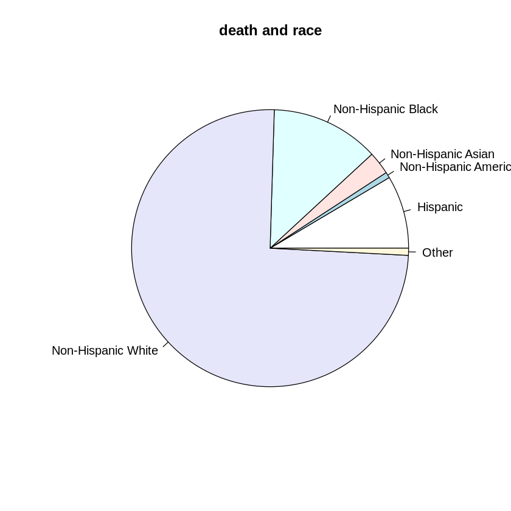

```r
A <- aggregate(total_death_count ~ Race.Ethnicity,data=data, sum)
pie(A$total_death_count, labels= A$Race.Ethnicity, main= "death and race")
#ethnic_cat <- aggregate(total ~ data$Race.Ethnicity, data =data,sum)
#pie(x = data$total_death_count, labels = data$Race.Ethnicity, main= "ethnicity wise death counts")
```

The resulting pie chart visually represents the distribution of deaths among different racial and ethnic groups. Each slice of the pie represents a unique race or ethnicity category, and the size of each slice is proportional to the total death count for that category. This visualization allows you to quickly grasp the relative proportions of deaths among different racial and ethnic groups in your dataset.As seen in the pie chart, Non hispanic white forms the major chunk of the pie. This is most likely to be proportional to population data.

## 2. Bar Graph for age wise death count

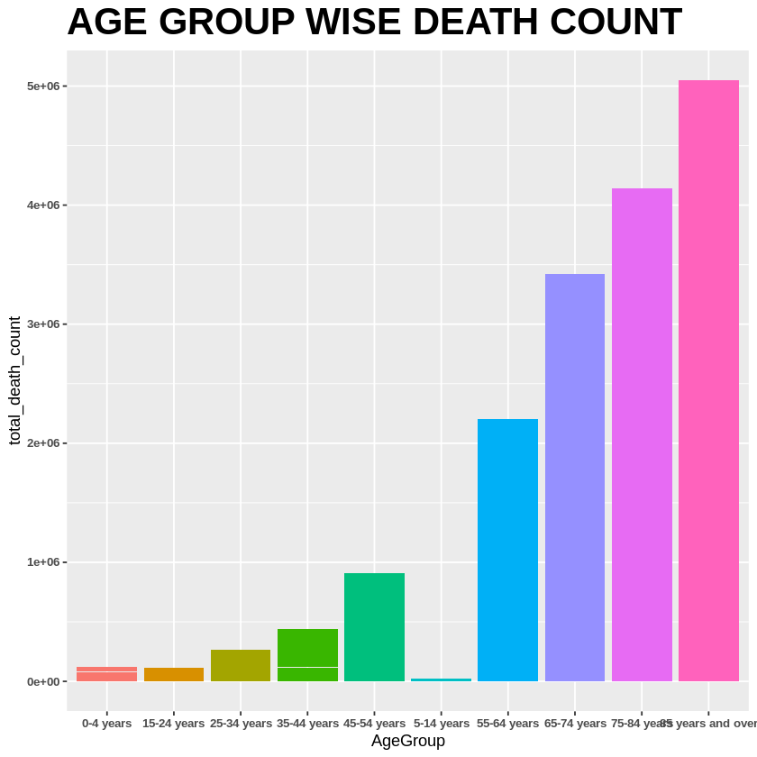

```r
library(ggplot2)

# Create a bar chart using ggplot2
ggplot(data, aes(x = AgeGroup, y = total_death_count, fill = AgeGroup)) +
  geom_bar(stat = "identity") +
  labs(title = "death count group wise", x = "AgeGroup", y = "total_death_count") +
  theme(legend.position = "none",
                     axis.text = element_text(size = 8,face="bold"),
        plot.title = element_text(size=25,face = "bold")) +
  ggtitle("AGE GROUP WISE DEATH COUNT")
```

Age group wise death count : bar chart that displays the death count for different age groups. Each bar represents an age group, and the height of the bar corresponds to the total death count for that group. It provides a clear visual representation of death counts across age groups, allowing for easy comparisons and insights into the distribution of deaths within different age categories. Clearly, progressive increase in age group positively co-relates to the death count

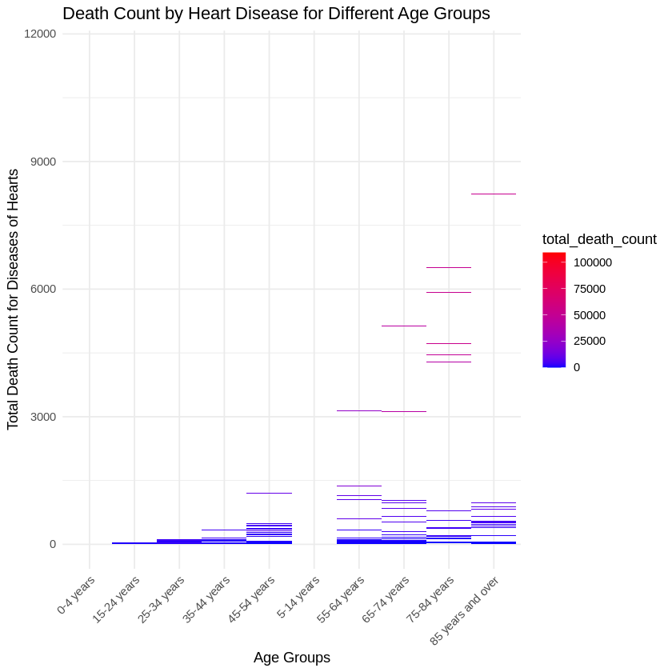

```r
library(ggplot2)
library(tidyverse)

ggplot(data, aes(x = AgeGroup, y = Diseases.of.heart..I00.I09.I11.I13.I20.I51., fill = total_death_count)) +
  geom_tile() +
  scale_fill_gradient(low = "blue", high = "red") +
  theme_minimal() +
  labs(title = "Death Count by Heart Disease for Different Age Groups",
       x = "Age Groups",
       y = "Total Death Count for Diseases of Hearts") +
  theme(axis.text.x = element_text(angle = 45, hjust = 1))
```

This heat map visually represents the death count for diseases of the heart across different age groups. Each tile's color intensity corresponds to the total death count, with blue indicating lower counts and red indicating higher counts. This visualization allows for easy identification of patterns and trends in heart disease mortality by age group, making it a valuable tool for data exploration and analysis in the project. It can be seen that 55+ age groups significantly high incidence of death count

## 4. Line Graph for Monthly trend of death counts

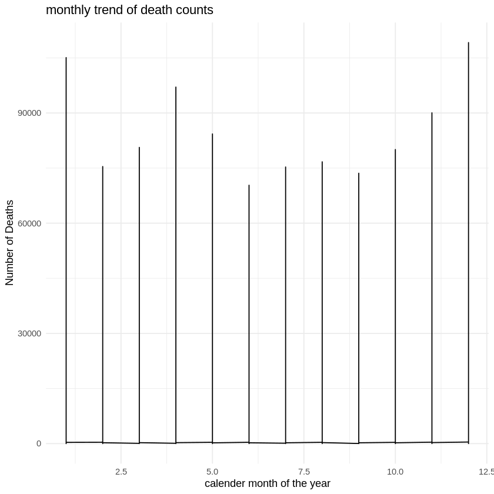

```r
ggplot(data, aes(x=Date.Of.Death.Month, y=total_death_count)) +   geom_line() +   labs(title="monthly trend of death counts", x="calender month of the year", y="Number of Deaths") +   theme_minimal()
```

This visualization of line graph plots calender months on X axis (with 1 denoting the month of January & 12 denoting the month of December) vs death counts on Y axis. This graph is particularly useful for tracking and analyzing the temporal patterns and trends in death counts over the year. It can help identify any seasonal variations or notable spikes in mortality, providing valuable insights for public health research and policy planning.

# **6. Explore Correlation**

```r
# Install package and library to create correlation plot
install.packages('corrplot')
library(corrplot)
```

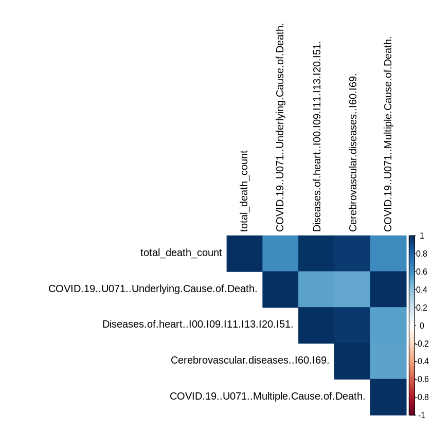

```r
#create a correlation matrix to plot find correlation between different columns
correlation_matrix <- cor(data[c("total_death_count","COVID.19..U071..Underlying.Cause.of.Death.", "Diseases.of.heart..I00.I09.I11.I13.I20.I51.", "Cerebrovascular.diseases..I60.I69.", "COVID.19..U071..Multiple.Cause.of.Death.")])

corrplot(correlation_matrix, method = "color", type = "upper", tl.col = "black", tl.srt = 90)
```

Dark blue cells indicate strong positive correlations between the corresponding variables. So a pair of variables represented by a dark blue cell suggests that when one variable increases, the other tends to increase as well. In the above heatmap, we have tried to find coorelation between different type of diseases & death count

Dark red cells indicate strong negative correlations. In this case, there isn't any. The intensity of color provides a visual cue for the strength of the relationship. Darker colors suggest stronger relationships, while lighter colors suggest weaker or no relationships.

## **7. Response Variable**

**Numerical Continuous Response Variable:**The numerical continuous response variable used in the models represents the number of deaths due to different causes. This variable is likely a count or rate of deaths for specific causes, such as COVID-19 deaths, heart disease deaths, or deaths related to symptoms and signs.

**Why This Variable Was Selected:** The choice of this variable is driven by the importance of understanding the factors influencing mortality rates for various causes, especially in the context of public health or medical research. Analyzing these relationships can provide insights into risk factors, disease prevalence, and the impact of different variables on the number of deaths, which can inform healthcare policies and interventions.

**Expectations:**The expectation in analyzing these models is to identify and quantify the relationships between the predictor variables (e.g., age, other factors) and the number of deaths for specific causes. These models can help answer questions like "How does age affect the number of deaths due to a particular cause?" or "Are there any statistically significant relationships between certain factors and cause-specific mortality rates?" The project aims to provide insights and evidence for better understanding and managing public health challenges related to mortality.

# **8.Linear Regression**

**8.1 Deaths due to Heart Disase vs Age Group**

```r
#Convert AgeGroup to a numerical variable (for simplification, we're treating age groups as mid-points)
data$AgeNumeric <- as.numeric(factor(data$AgeGroup, levels = unique(data$AgeGroup)))
model <- lm(Diseases.of.heart..I00.I09.I11.I13.I20.I51.	 ~ AgeNumeric, data=data)
summary(model)
```

```
Call:
lm(formula = Diseases.of.heart..I00.I09.I11.I13.I20.I51. ~ AgeNumeric,
    data = data)

Residuals:
    Min      1Q  Median      3Q     Max
-1260.9  -576.2  -196.9   162.6 10232.1

Coefficients:
            Estimate Std. Error t value Pr(>|t|)
(Intercept) -516.690     45.655  -11.32   <2e-16 ***
AgeNumeric   178.658      7.358   24.28   <2e-16 ***
---
Signif. codes:  0 ‘***’ 0.001 ‘**’ 0.01 ‘*’ 0.05 ‘.’ 0.1 ‘ ’ 1

Residual standard error: 1330 on 3958 degrees of freedom
Multiple R-squared:  0.1296,	Adjusted R-squared:  0.1294
F-statistic: 589.6 on 1 and 3958 DF,  p-value: < 2.2e-16
```

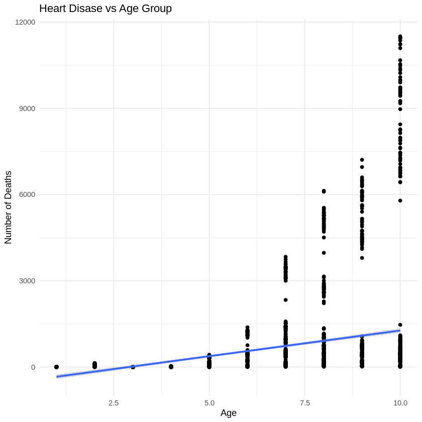

```r
library(ggplot2)

ggplot(data, aes(x=AgeNumeric, y=Diseases.of.heart..I00.I09.I11.I13.I20.I51.	)) +
  geom_point() +
  geom_smooth(method="lm") +
  labs(title="Heart Disase vs Age Group", x="Age", y="Number of Deaths") +
  theme_minimal()
```

The graph shows how age relates to the number of deaths caused by heart diseases. Each point on the graph represents a specific age group, and the height of the point tells us how many people in that age group passed away due to heart diseases. The line through the points helps us see the overall trend. In essence, this model helps the stakeholder understand how age influences heart disease deaths, enabling them to take targeted actions to improve mortality and improve public health outcomes.

**8.2 Deaths due to Cerebrovascular Disease vs Age Group**

```
Call:
lm(formula = Cerebrovascular.diseases..I60.I69. ~ AgeNumeric,
    data = data)

Residuals:
   Min     1Q Median     3Q    Max
-305.5 -127.8  -41.4   46.9 3176.5

Coefficients:
            Estimate Std. Error t value Pr(>|t|)
(Intercept) -135.268     11.203  -12.07   <2e-16 ***
AgeNumeric    44.177      1.806   24.47   <2e-16 ***
---
Signif. codes:  0 ‘***’ 0.001 ‘**’ 0.01 ‘*’ 0.05 ‘.’ 0.1 ‘ ’ 1

Residual standard error: 326.3 on 3958 degrees of freedom
Multiple R-squared:  0.1314,	Adjusted R-squared:  0.1312
F-statistic: 598.6 on 1 and 3958 DF,  p-value: < 2.2e-16
```

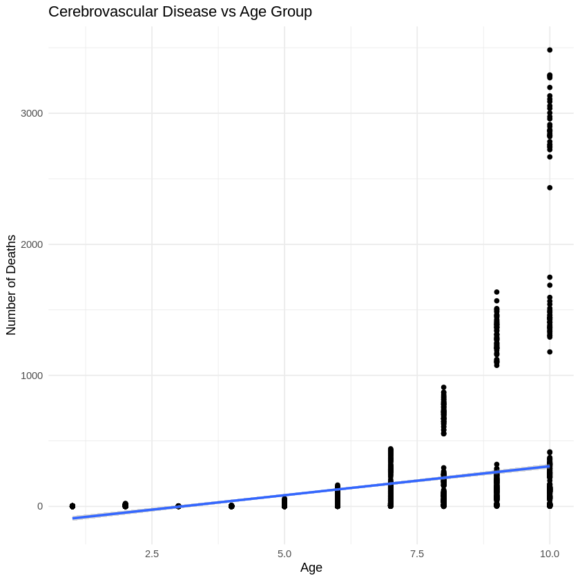

```r
data$AgeNumeric <- as.numeric(factor(data$AgeGroup, levels = unique(data$AgeGroup)))

model <- lm(Cerebrovascular.diseases..I60.I69.  ~ AgeNumeric, data=data)

summary(model)

library(ggplot2)



ggplot(data, aes(x=AgeNumeric, y= Cerebrovascular.diseases..I60.I69. )) +

  geom_point() +

  geom_smooth(method="lm") +

  labs(title="Cerebrovascular Disease vs Age Group", x="Age", y="Number of Deaths") +

  theme_minimal()
```

The chart illustrates the correlation between age and fatalities attributed to Cerebrovascular Disease. Each data point corresponds to a distinct age group, with its vertical position indicating the number of individuals from that age category who succumbed to Cerebrovascular Disease. The trend line, spanning across these data points, provides a clear overview of the broader pattern. Essentially, this model equips stakeholders in the business sector to grasp the impact of age on Cerebrovascular deaths, enabling them to implement tailored strategies to enhance public health outcomes and reduce mortality rates.

**8.3 Deaths due to symptoms, signs and abnormal clinical and laboratory findings Vs Age**

```r
#Convert AgeGroup to a numerical variable (for simplification, we're treating age groups as mid-points)
data$AgeNumeric <- as.numeric(factor(data$AgeGroup, levels = unique(data$AgeGroup)))
model <- lm(Symptoms..signs.and.abnormal.clinical.and.laboratory.findings..not.elsewhere.classified..R00.R99.		 ~ AgeNumeric, data=data)
summary(model)
```

```
Call:
lm(formula = Symptoms..signs.and.abnormal.clinical.and.laboratory.findings..not.elsewhere.classified..R00.R99. ~
    AgeNumeric, data = data)

Residuals:
    Min      1Q  Median      3Q     Max
 -59.40  -34.99  -18.44   -3.73 1266.16

Coefficients:
            Estimate Std. Error t value Pr(>|t|)
(Intercept)   0.8811     3.0711   0.287    0.774
AgeNumeric    5.8515     0.4949  11.823   <2e-16 ***
---
Signif. codes:  0 ‘***’ 0.001 ‘**’ 0.01 ‘*’ 0.05 ‘.’ 0.1 ‘ ’ 1

Residual standard error: 89.46 on 3958 degrees of freedom
Multiple R-squared:  0.03411,	Adjusted R-squared:  0.03387
F-statistic: 139.8 on 1 and 3958 DF,  p-value: < 2.2e-16
```

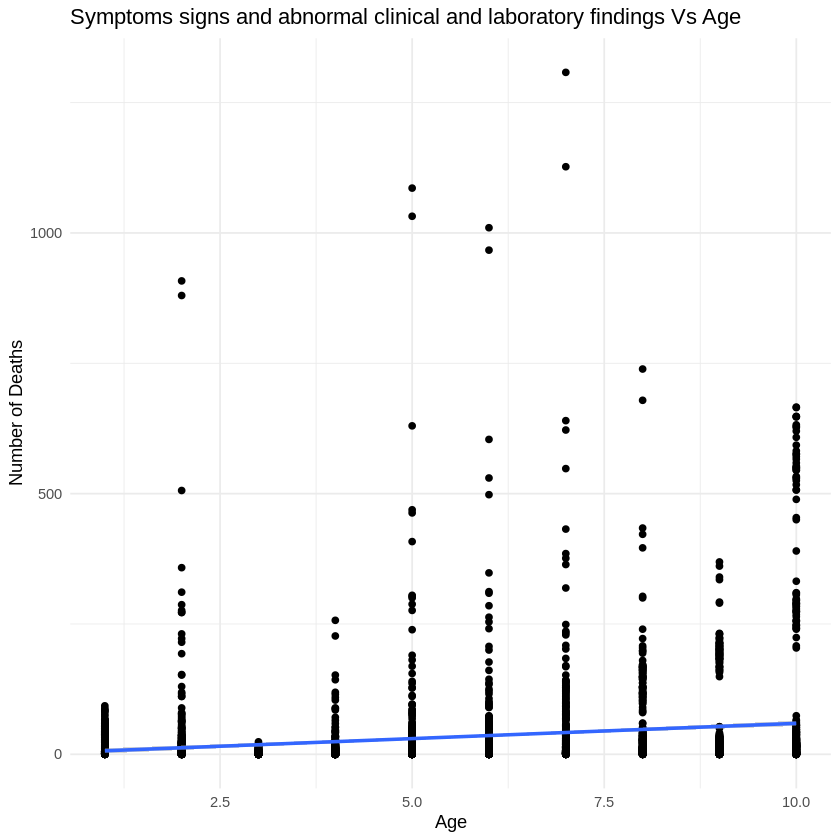

```r
ggplot(data, aes(x=AgeNumeric, y=Symptoms..signs.and.abnormal.clinical.and.laboratory.findings..not.elsewhere.classified..R00.R99.	)) +
  geom_point() +
  geom_smooth(method="lm") +
  labs(title="Symptoms signs and abnormal clinical and laboratory findings Vs Age", x="Age", y="Number of Deaths") +
  theme_minimal()
```

**8.4 Deaths due to Diabetes vs Age Group**

```r
data$AgeNumeric <- as.numeric(factor(data$AgeGroup, levels = unique(data$AgeGroup)))
model <- lm(Diabetes.mellitus..E10.E14.	 ~ AgeNumeric, data=data)
summary(model)
```

```
Call:
lm(formula = Diabetes.mellitus..E10.E14. ~ AgeNumeric, data = data)

Residuals:
    Min      1Q  Median      3Q     Max
-161.90  -69.18  -20.59   21.19  919.62

Coefficients:
            Estimate Std. Error t value Pr(>|t|)
(Intercept) -50.7180     4.7475  -10.68   <2e-16 ***
AgeNumeric   21.2620     0.7651   27.79   <2e-16 ***
---
Signif. codes:  0 ‘***’ 0.001 ‘**’ 0.01 ‘*’ 0.05 ‘.’ 0.1 ‘ ’ 1

Residual standard error: 138.3 on 3958 degrees of freedom
Multiple R-squared:  0.1632,	Adjusted R-squared:  0.163
F-statistic: 772.2 on 1 and 3958 DF,  p-value: < 2.2e-16
```

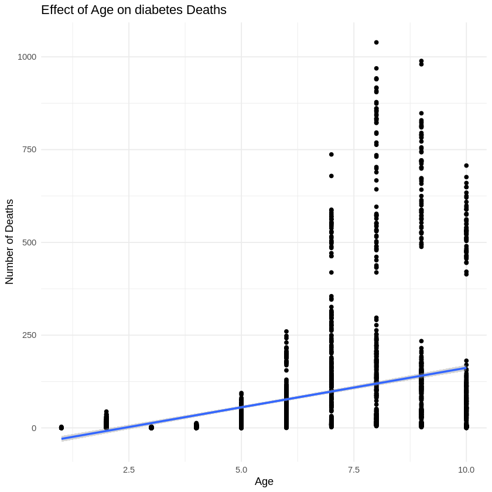

```r
ggplot(data, aes(x=AgeNumeric, y=Diabetes.mellitus..E10.E14.	)) +
  geom_point() +
  geom_smooth(method="lm") +
  labs(title="Effect of Age on diabetes Deaths", x="Age", y="Number of Deaths") +
  theme_minimal()
```

The chart depicts the correlation between age and diabetes-related fatalities. Each data point corresponds to a particular age bracket, with its vertical position indicating the diabetes-related death count in that group. The trend line running through the points provides a clear overview of the overall pattern. Essentially, this model facilitates stakeholder comprehension of how age impacts diabetes-related mortality, empowering them to implement specific measures for better mortality rates and enhanced public health outcomes.

**8.5 Deaths due to Pneumonia & Influenza Vs Age**

```r
data$AgeNumeric <- as.numeric(factor(data$AgeGroup, levels = unique(data$AgeGroup)))
model <- lm(Influenza.and.pneumonia..J09.J18.	 ~ AgeNumeric, data=data)
summary(model)
```

```
Call:
lm(formula = Influenza.and.pneumonia..J09.J18. ~ AgeNumeric,
    data = data)

Residuals:
    Min      1Q  Median      3Q     Max
 -89.78  -38.78  -14.54   10.55 1126.22

Coefficients:
            Estimate Std. Error t value Pr(>|t|)
(Intercept) -35.6291     3.2598  -10.93   <2e-16 ***
AgeNumeric   12.5414     0.5254   23.87   <2e-16 ***
---
Signif. codes:  0 ‘***’ 0.001 ‘**’ 0.01 ‘*’ 0.05 ‘.’ 0.1 ‘ ’ 1

Residual standard error: 94.96 on 3958 degrees of freedom
Multiple R-squared:  0.1259,	Adjusted R-squared:  0.1256
F-statistic: 569.9 on 1 and 3958 DF,  p-value: < 2.2e-16
```

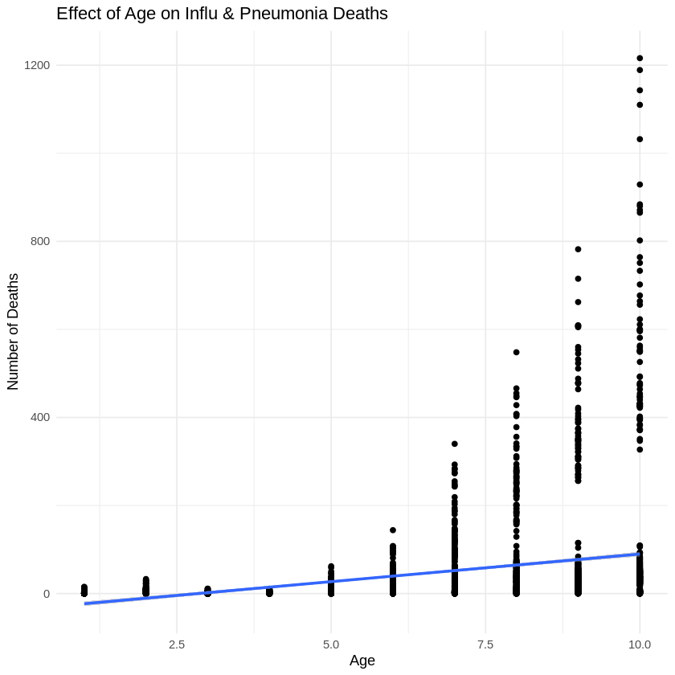

```r
ggplot(data, aes(x=AgeNumeric, y=Influenza.and.pneumonia..J09.J18.	)) +
  geom_point() +
  geom_smooth(method="lm") +
  labs(title="Effect of Age on Influ & Pneumonia Deaths", x="Age", y="Number of Deaths") +
  theme_minimal()
```

The graph illustrates the connection between age and deaths caused by Pneumonia & Influenza. Each data point represents a distinct age group, and its height signifies the number of deaths attributed to Pneumonia & Influenza within that group. The trend line, which traverses the data points, offers a concise summary of the general trend. In essence, this model aids stakeholders in understanding how age influences mortality linked to Pneumonia & Influenza, enabling them to devise targeted strategies to enhance public health outcomes and reduce mortality rates.

## **Comparing Models**

To compare the five simple linear regression models and determine which one is the best choice, let's examine their key characteristics:

**Model 1 (Diseases of the Heart):**

- R-squared: 0.1296
- Residual standard error: 1330
- Coefficient for AgeNumeric: 178.658

**Model 2 (Cerebrovascular Diseases):**

- R-squared: 0.1314
- Residual standard error: 326.3
- Coefficient for AgeNumeric: 44.177

**Model 3 (Symptoms, Signs, and Abnormal Clinical Findings):**

- R-squared: 0.03411
- Residual standard error: 89.46
- Coefficient for AgeNumeric: 5.8515

**Model 4 (Diabetes Mellitus):**

- R-squared: 0.1632
- Residual standard error: 138.3
- Coefficient for AgeNumeric: 21.2620

**Model 5 (Influenza and Pneumonia):**

- R-squared: 0.1259
- Residual standard error: 94.96
- Coefficient for AgeNumeric: 12.5414

To analyse the models -

Therefore, based on these metrics, **Model 4 (Diabetes Mellitus)** appears to be the best choice for analyzing the relationship between age and health issues among the five models. It indicates that age is a significant predictor of diabetes mellitus.